# Multivariate Optimum Stratification with multistrata

Karuna G. Reddy and M. G. M. Khan

## Overview

`multistrata` solves the *joint* multivariate survey design problem: it determines optimal strata boundaries across several stratification variables **and** the optimal sample allocation across the resulting strata, *simultaneously*, by minimising the weighted composite variance

$$\Phi(\mathbf{B}, \mathbf{n}) \;=\;
\sum_{k=1}^{q} \omega_k\,
V_k(\mathbf{B}, \mathbf{n}),$$

where $V_k$ is the variance of the stratified mean estimator of the $k$-th study variable. The package extends the univariate, density-based `stratifyR` framework (Reddy & Khan, 2018) to any number of stratification and study variables, and supports both data-based and data-free design workflows.

The optimiser is a multi-start alternating scheme (MSAO): a boundary update (COBYLA, or gradient-based SLSQP in parametric mode) alternates with a closed-form generalised Neyman allocation, and the best of many random starts is retained. A Cauchy–Schwarz calculation reports the allocation gap at the returned boundaries; it does not certify the non-convex boundary search.

## Two ways to use the package

Everything in this vignette can be driven either from the **R console** (the code shown throughout) or from the **bundled interactive application**, whichever you prefer. The two are interchangeable because every result the app produces is computed by the exported functions documented below.

The package ships a companion application that exposes the entire workflow with no coding. Launch it with:

```r
library(multistrata)
run_app()
```

`run_app()` opens the app in a standalone window (or your default browser). In it you (1) choose a data source: a shipped example population, an uploaded CSV/Excel frame, a simulated population, or a data-free *densities only* specification; (2) select the stratification and study variables and set the number of strata per variable, the total sample size or budget, the priority weights `omega`, and any coefficient-of-variation targets; (3) pick the weight mode (empirical, parametric, or auto-parametric AIC selection) and the solver (COBYLA or SLSQP); and (4) run the joint optimiser. Results appear as stratum tables, allocation and boundary diagrams, interactive plots, benchmark comparisons, `find_n()` and `choose_H()` tools, and an `omega` trade-off explorer. Results are downloadable, and the **R Code** tab writes a reproducible script that recreates the design with the package alone.

The interface packages are optional (they live in `Suggests`); install them once with `install.packages(c("shiny", "bslib", "DT", "jsonlite"))`. The rest of this vignette shows the same operations programmatically, which is what you will use for scripted, reproducible pipelines.

## A first design (empirical mode)

This mirrors Scenario A of the paper on a smaller population for speed: $X_1 \sim \text{LogNormal}(1.0,\,0.75)$, $X_2 \sim \text{Gamma}(2,\,1.5)$, with two correlated study variables.

```r
library(multistrata)

N  <- 4000
X1 <- rlnorm(N, meanlog = 1.0, sdlog = 0.75)
X2 <- rgamma(N, shape = 2, rate = 1.5)
Y1 <- 2.0 * X1 + 0.5 * X2 + rnorm(N, 0, 1.0)
Y2 <- 0.3 * X1 + 1.8 * X2 + rnorm(N, 0, 1.5)
pop <- data.frame(X1, X2, Y1, Y2)
```

```r
res_emp <- stratify_multi(
  data       = pop[, c("X1", "X2")],
  study_vars = pop[, c("Y1", "Y2")],
  H_vec      = c(3, 3),          # 3 x 3 = 9 strata
  n_total    = 500,
  omega      = c(0.5, 0.5),
  n_starts   = 10
)
print(res_emp)
```

```
#>
#> ================================================
#>   Multivariate Optimum Stratification (multistrata)
#> ================================================
#>   Stratification variables : 2  (X1, X2)
#>   Study variables          : 2  (Y1, Y2)
#>   Strata per variable      : 3 x 3
#>   Total strata             : 9
#>   Population size (N)      : 4000
#>   Total sample (n)         : 500
#>   Constraint type          : n_total
#>   Weight mode              : empirical
#>   Boundary solver          : COBYLA
#> ------------------------------------------------
#>   Composite variance (Phi) : 0.0090
#>   Optimality gap           : 0.00%
#>   KKT residual (scaled)    : 2.51e-02  [>= tol_kkt]
#>   Converged                : YES
#>   Multi-starts used        : 10
#> ------------------------------------------------
#>   Optimal strata boundaries:
#>     X1: [0.2168 | 2.9759 | 6.9827 | 39.9846]
#>     X2: [0.0240 | 0.9523 | 1.6111 | 8.0612]
```

## The parametric mode

When a credible parametric family is available for each stratification variable, stratum weights are computed analytically from marginal CDF increments (Section 3.5 of the paper). This smooths the objective surface, removes count noise from sparse cells, and typically lowers both the achieved composite variance and the optimality gap.

```r
dists <- list(
  X1 = list(family = "lnorm", meanlog = 1.0, sdlog = 0.75),
  X2 = list(family = "gamma", shape   = 2.0, rate  = 1.5)
)

res_par <- stratify_multi(
  data       = pop[, c("X1", "X2")],
  study_vars = pop[, c("Y1", "Y2")],
  H_vec      = c(3, 3),
  n_total    = 500,
  omega      = c(0.5, 0.5),
  n_starts   = 10,
  distributions = dists
)
print(res_par)
```

```
#>
#> ================================================
#>   Multivariate Optimum Stratification (multistrata)
#> ================================================
#>   Stratification variables : 2  (X1, X2)
#>   Study variables          : 2  (Y1, Y2)
#>   Strata per variable      : 3 x 3
#>   Total strata             : 9
#>   Population size (N)      : 4000
#>   Total sample (n)         : 500
#>   Constraint type          : n_total
#>   Weight mode              : parametric
#>   Boundary solver          : COBYLA
#> ------------------------------------------------
#>   Composite variance (Phi) : 0.0088
#>   Optimality gap           : 0.00%
#>   KKT residual (scaled)    : 3.16e-01  [>= tol_kkt]
#>   Converged                : YES
#>   Multi-starts used        : 10
#> ------------------------------------------------
#>   Optimal strata boundaries:
#>     X1: [0.2168 | 2.4843 | 6.8896 | 39.9846]
#>     X2: [0.0240 | 1.1267 | 2.0274 | 8.0612]
```

```r
relative_efficiency(res_par$objective, res_emp$objective)
```

```
#> [1] 1.018945
```

In practice the parameters are estimated from the frame, e.g. with `MASS::fitdistr(X1, "lognormal")`, or with a dedicated distribution-fitting package such as `FitVerse`.

### Auto-parametric mode

If you prefer to delegate the distributional judgement entirely, pass `distributions = "auto"`: each stratification variable is fitted against a catalogue of candidate families, scored by AIC using the package’s own density constructors, and the winner is used for the analytic weights. When the `FitVerse` package is installed, its fitting engine competes on the shared families and the overall AIC winner is retained.

```r
res_auto <- stratify_multi(
  data       = pop[, c("X1", "X2")],
  study_vars = pop[, c("Y1", "Y2")],
  H_vec      = c(3, 3),
  n_total    = 500,
  n_starts   = 10,
  distributions = "auto"
)
# which families were selected, and the full AIC table:
sapply(res_auto$.meta$distributions, function(d) d$family)
```

```
#>      X1      X2
#> "lnorm" "gamma"
```

```r
head(res_auto$.meta$auto_fit)
```

```
#>    variable  family                       params    logLik      AIC   engine
#> 1        X1   lnorm meanlog=0.9895, sdlog=0.7512 -8489.509 16983.02  builtin
#> 10       X1   lnorm meanlog=0.9894, sdlog=0.7512 -8489.509 16983.02 FitVerse
#> 2        X1   gamma     shape=1.919, rate=0.5378 -8671.579 17347.16  builtin
#> 3        X1 weibull     shape=1.327, scale=3.916 -8819.525 17643.05  builtin
#> 5        X1     exp                  rate=0.2802 -9088.332 18178.66  builtin
#> 7        X1  cauchy  location=2.443, scale=1.125 -9452.690 18909.38  builtin
```

The standalone fitter is also exported:

```r
dl <- fit_distributions(pop[, c("X1", "X2")], verbose = TRUE)
attr(dl, "chosen")
```

## Gradient-based boundary search (SLSQP)

Under the parametric mode the weight gradient $\partial W_{\mathbf h}/\partial b$ is available in closed form, so the boundary sub-problem can also be solved with the gradient-based SLSQP algorithm:

```r
res_slsqp <- stratify_multi(
  data       = pop[, c("X1", "X2")],
  study_vars = pop[, c("Y1", "Y2")],
  H_vec      = c(3, 3),
  n_total    = 500,
  n_starts   = 10,
  method     = "slsqp",
  distributions = dists
)
res_slsqp$objective
```

```
#> [1] 0.009397645
```

## Constraints: cost and coefficients of variation

Cost-constrained designs replace the sample-size constraint with a budget $c_0 + \sum_{\mathbf h} c_{\mathbf h} n_{\mathbf h} \le C^*$ (Theorem 1(c) of the paper):

```r
res_cost <- stratify_multi(
  data = pop[, c("X1", "X2")], study_vars = pop[, c("Y1", "Y2")],
  H_vec = c(3, 3), n_total = 500,
  constraint = "cost", cost_total = 1200, cost_fixed = 100,
  cost_per_unit = 2, n_starts = 10
)
```

Maximum coefficients of variation per study variable (constraint (C3)) turn the allocation step into a convex programme, solved internally by SLSQP. Targets must be attainable at the given sample size; a practical way to set them is relative to the CVs of an unconstrained baseline design:

```r
ss  <- res_par$stratum_stats
cv0 <- design_cv(
  sigma2  = as.matrix(ss[, c("sigma2_k1", "sigma2_k2")]),
  mu      = as.matrix(ss[, c("mu_k1", "mu_k2")]),
  W_h     = ss$W_h,
  n_alloc = res_par$allocation,
  N_h     = ss$N_h)
cv0                                   # CVs of the unconstrained design
```

```
#>      CV_Y1      CV_Y2
#> 0.01378827 0.02270099
```

```r
res_cv <- stratify_multi(
  data = pop[, c("X1", "X2")], study_vars = pop[, c("Y1", "Y2")],
  H_vec = c(3, 3), n_total = 500, n_starts = 5,
  cv_targets = as.numeric(cv0) * c(0.98, 1.10)  # tighten Y1, relax Y2
)
res_cv$cv_achieved
```

```
#> [1] 0.01351376 0.02349286
```

Unattainable targets do not fail: the design is returned with a warning and the achieved CVs, so you can judge how much additional sample would be needed.

## Inverse design and choosing the number of strata

Two common operational questions have direct helpers. *“What is the smallest sample that meets my precision targets?”* is answered by `find_n()`, which bisects the total sample size subject to coefficient-of-variation targets on every study variable (reusing the CV-constrained allocation machinery):

```r
fn <- find_n(pop[, c("X1", "X2")], pop[, c("Y1", "Y2")],
             cv_targets = c(0.05, 0.05), result = res_par)
fn          # smallest feasible n, the allocation, and the achieved CVs
```

*“How many strata should I use?”* is answered by `choose_H()`, which traces $\Phi^\*$ across candidate grids and flags the elbow beyond which further subdivision buys little precision:

```r
ch <- choose_H(pop[, c("X1", "X2")], pop[, c("Y1", "Y2")],
               n_total = 400, H_each = 2:5, plot = TRUE)
ch$recommended
```

## Deploying a design: scoring a frame and exporting to survey

Once a design is estimated it is reused operationally. `assign_strata()` scores any frame (the estimation frame, a fresh census extract, hold-out data) into the optimal strata, and `as_svydesign()` turns a drawn sample into a ready-to-analyse object for the **survey** package (or, with `frame_only = TRUE`, a data frame for **srvyr**), attaching the design weights $N_h/n_h$ and finite-population corrections:

```r
strata <- assign_strata(res_par, pop[, c("X1", "X2")])   # factor of stratum labels
des    <- as_svydesign(res_par, sample_data = my_sample) # survey.design object
```

## Data-free density mode

When the stratification variables are *themselves* the study variables, the design can be built from the marginal densities alone, with **no population data frame at all**. `stratify_multi_density()` computes the stratum weights from the marginal CDFs and the stratum means and variances by quadrature of the marginal densities, then runs the same optimiser as `stratify_multi()`. This is the exact analogue of the density-based LINGO formulation, free of sampling noise; the empirical mode converges to it as $N \to \infty$.

```r
# Exponential(1) x right-triangular(0,2), 4 x 3 = 12 strata, N = 2000, n = 700,
# with no data supplied, only the densities and their supports.
res_den <- stratify_multi_density(
  distributions = list(x = list(family = "exp",    rate = 1),
                       y = list(family = "triang", a = 0, b = 2, c = 0)),
  H_vec   = c(4, 3), n_total = 700, N = 2000,
  ranges  = list(c(0, 10), c(0, 2)))
print(res_den)
res_den$boundaries
```

Supply `ranges` to fix a truncated support (here the exponential is capped at 10); otherwise each range defaults to the family’s extreme quantiles. `print()` and `summary()` apply as usual, but `plot_strata()` does not, there is no realised data to scatter.

The density workflow has the same downstream decision helpers as the empirical workflow. These are useful when no microdata are available but the survey designer still needs to justify the design against simpler alternatives, choose a sample size, decide how many strata to use, or check sensitivity to priority weights.

```r
# Benchmark against proportional, equal and density-quantile + Neyman designs.
benchmark_density_designs(result_joint = res_den)

# Smallest n that satisfies target CVs for both variables.
fn_den <- find_n_density(result = res_den, cv_targets = c(0.05, 0.05))
fn_den$n

# Trace the optimum as the number of strata per variable increases.
ch_den <- choose_H_density(
  distributions = list(x = list(family = "exp",    rate = 1),
                       y = list(family = "triang", a = 0, b = 2, c = 0)),
  n_total = 700, N = 2000, H_each = 2:5,
  ranges = list(c(0, 10), c(0, 2)),
  plot = TRUE)
ch_den$recommended

# Sweep the priority weight assigned to the first variable.
omega_sweep_density(
  distributions = list(x = list(family = "exp",    rate = 1),
                       y = list(family = "triang", a = 0, b = 2, c = 0)),
  H_vec = c(4, 3), n_total = 700, N = 2000,
  ranges = list(c(0, 10), c(0, 2)),
  grid = seq(0.1, 0.9, length.out = 5))
```

## Benchmarking against simpler designs

`benchmark_designs()` operationalises Lemma 1 of the paper: sequential procedures (boundaries first, allocation second) are in general strictly sub-optimal relative to the joint optimum.

```r
bench <- benchmark_designs(
  data       = pop[, c("X1", "X2")],
  study_vars = pop[, c("Y1", "Y2")],
  H_vec      = c(3, 3),
  n_total    = 500,
  omega      = c(0.5, 0.5),
  result_joint = res_par
)
bench
```

```
#>                           method composite_variance relative_efficiency
#> 1            Joint (multistrata)         0.00879364              1.0000
#> 2        Proportional allocation         0.01257131              1.4296
#> 3               Equal allocation         0.01053781              1.1983
#> 4 Sequential (quantile + Neyman)         0.01328718              1.5110
#>   pct_gain_over_joint
#> 1                0.00
#> 2               42.96
#> 3               19.83
#> 4               51.10
```

## Visualising the design

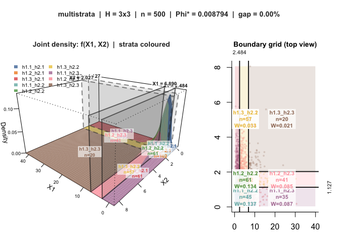

```r
plot_strata(res_par, data = pop[, c("X1", "X2")],
            study_vars = pop[, c("Y1", "Y2")])
```

## Shipped example populations

Three fictitious populations are included for experimentation: `pacific_agri` (8000 farms; the real-data application of the paper), `business_survey` (5000 enterprises) and `health_survey` (6000 individuals).

```r
data(pacific_agri)
res_agri <- stratify_multi(
  data       = pacific_agri[, c("land_area", "labour_units")],
  study_vars = pacific_agri[, c("crop_yield", "livestock_value", "expenditure")],
  H_vec      = c(4, 3),
  n_total    = 600,
  omega      = c(0.4, 0.4, 0.2),
  distributions = list(
    land_area    = list(family = "lnorm", meanlog = 0.9,  sdlog = 0.85),
    labour_units = list(family = "gamma", shape   = 2.2,  rate  = 0.9)
  )
)
```

## Companion Shiny application

An interactive application built on this package ships **inside the package itself**, installed under `inst/shiny/`. It exposes the full workflow, data upload or simulation, both weight modes (including auto-parametric selection with a per-variable AIC table), all constraint types, and both solvers, plus interactive visualisations that go beyond the static figures here: a boundary map with per-stratum annotations, a rotatable 3-D explorer with boundary planes, kernel-density contours, a 3-D density ridge with FitVerse best-fit overlays, scatter-plot matrices for $p \ge 3$, an $\omega$ trade-off explorer, and a generator for reproducible R scripts. A dedicated *Densities only* data source runs the data-free mode described above, with matching joint-density boundary maps, 3-D density surfaces and contours in place of the data-cloud views. Launch it with `run_app()`, as shown at the top of this vignette.

## References

Reddy, K. G. & Khan, M. G. M. (2018). stratifyR: An R Package for optimal stratification and sample allocation for univariate populations. *Australian & New Zealand Journal of Statistics*.